# Version comparison: Program-Area / Planning-Area scores

Parameterized report — overall composite and every component score, two releases side by side

Published

2026-09-03

> **Not a pipeline stage** — a standalone, parameterized *report* (no `msens:` target block, so `tar_make()` never runs it). Render it on demand for any two release versions whose `sdm.duckdb` are on disk. The reusable comparison **core lives in `msens`** (`zone_scored_flds`, `zone_scores`, `zone_crosswalk`, `zone_score_delta`, `score_delta`, `score_delta_summary`, `assert_within_tolerance`) so this notebook only *orchestrates* — the math is unit-tested in `msens/tests/testthat/test-validate.R` and can’t drift from what’s reported here.

> ```r
> # render with version suffixes in the output filename (see scripts/render_compare.R):
> source("scripts/render_compare.R"); render_compare("v6", "v9")   # -> _output/compare_versions_v6_vs_v9.html
> # or from the shell:
> Rscript scripts/render_compare.R v6 v9
> ```

> **What is compared.** Scores on each release’s **principal reporting unit** — the 20 BOEM **Program Areas** (v2 onward) or, for a release that scored none, the 36 **Planning Areas** (v1). Ecoregions and subregions are deliberately not reported here. When the two releases used different units, zones are compared **only where they are the same polygon** (`msens::zone_crosswalk()`, intersection over union ≥ 0.999, computed from the polygons at render time); everything else — a Program Area that is a *subset* of a Planning Area, a Planning Area with no Program Area — is listed **adjacent, not compared**, exactly as components present in only one release (v6’s `other`, v8+’s `primary_producer`) are. The overall composite and each **component** it averages (`extrisk_{category}_ecoregion_rescaled` + `primprod_ecoregion_rescaled`) are shown. `Δ = B − A`.

## 1 Setup

```r
librarian::shelf(DBI, duckdb, dplyr, DT, ggplot2, glue, htmltools, knitr, leaflet, purrr,
                 rmapshaper, scales, sf, tidyr, MarineSensitivity/msens, quiet = TRUE)
source(here::here("libs/paths.R"))

va <- params$version_a
vb <- params$version_b
mk <- params$metric_key
stopifnot(va != vb)

# resolve each version's sdm.duckdb by swapping the version segment of the configured path
sdm_for <- function(v) sub(glue("/{ver}/"), glue("/{v}/"), path.expand(sdm_db))
db_a <- sdm_for(va); db_b <- sdm_for(vb)
stopifnot(file.exists(db_a), file.exists(db_b))

con_a <- dbConnect(duckdb(), db_a, read_only = TRUE)
con_b <- dbConnect(duckdb(), db_b, read_only = TRUE)

va_col <- glue("score_{va}"); vb_col <- glue("score_{vb}")

# the principal reporting unit each release actually scored: Program Areas if it has them, else
# Planning Areas (v1); never ecoregions or subregions
UNITS <- c(programarea = "programarea_key", planarea = "planarea_key")
unit_of <- function(con, v) {
  flds <- msens::zone_scored_flds(con, mk)
  u <- UNITS[UNITS %in% flds]
  if (!length(u)) stop(glue("{v}: no Program-Area or Planning-Area zones carry `{mk}` (has: ",
                            "{paste(flds, collapse = ', ')})"))
  names(u)[1]
}
unit_a <- unit_of(con_a, va); unit_b <- unit_of(con_b, vb)
fld_a  <- UNITS[[unit_a]];    fld_b  <- UNITS[[unit_b]]
unit_label <- c(programarea = "Program Area", planarea = "Planning Area")

cat(glue("Comparing **{va}** (A) ← → **{vb}** (B)  \n",
         "- A ({va}): `{db_a}` — scored on **{unit_label[[unit_a]]}s** (`{fld_a}`)  \n",
         "- B ({vb}): `{db_b}` — scored on **{unit_label[[unit_b]]}s** (`{fld_b}`)  \n",
         "- composite metric: `{mk}`\n"))
```

```
Comparing **v1** (A) ← → **v6** (B)
- A (v1): `/Users/bbest/_big/msens/derived/v1/sdm.duckdb` — scored on **Planning Areas** (`planarea_key`)
- B (v6): `/Users/bbest/_big/msens/derived/v6/sdm.duckdb` — scored on **Program Areas** (`programarea_key`)
- composite metric: `score_extriskspcat_primprod_ecoregionrescaled_equalweights`
```

### 1.1 Zone polygons

The choropleths and the crosswalk need each unit’s geometry. It is resolved from the derived tree by **content**, not by filename: every `ply_{unit}s_*.gpkg` under `dir_derived` is fingerprinted with `msens::zone_geom_hash()` and the first whose hash equals that unit’s entry in `data/zone_sets.csv` is used — so the map can never silently draw a different vintage than the scores were computed on.

```r
zone_sets <- readr::read_csv(here::here("data/zone_sets.csv"), show_col_types = FALSE)

resolve_ply <- function(unit) {
  zs <- zone_sets |> filter(zone_type == unit)
  stopifnot(nrow(zs) >= 1)
  zs <- zs[1, ]
  cands <- list.files(path.expand(dir_derived), pattern = glue("^ply_{unit}s_.*\\.gpkg$"),
                      recursive = TRUE, full.names = TRUE)
  for (f in cands) {
    x <- sf::st_read(f, quiet = TRUE)
    h <- tryCatch(msens::zone_geom_hash(x, zone_type = unit)$geom_hash, error = function(e) NA)
    if (identical(h, zs$geom_hash)) {
      key <- UNITS[[unit]]; nm <- glue("{unit}_name")
      x <- x |>
        transmute(zone_key = as.character(.data[[key]]), zone_name = .data[[nm]],
                  region = if ("region_key" %in% names(x)) region_key else NA_character_,
                  hint   = if ("planarea_key" %in% names(x) && unit != "planarea") planarea_key
                           else NA_character_) |>
        st_make_valid()
      attr(x, "src") <- f; attr(x, "zone_set_key") <- zs$zone_set_key
      return(x)
    }
  }
  stop(glue("no ply_{unit}s_*.gpkg under {dir_derived} matches geom_hash {zs$geom_hash} ",
            "({zs$zone_set_key}); candidates: {paste(cands, collapse = ', ')}"))
}
ply_a <- resolve_ply(unit_a)
ply_b <- if (unit_b == unit_a) ply_a else resolve_ply(unit_b)

for (p in unique(list(ply_a, ply_b)))
  cat(glue("- `{sub(path.expand(dir_derived), '', attr(p, 'src'))}` — {attr(p, 'zone_set_key')}, ",
           "{nrow(p)} zones\n\n"))
```

```
- `/archive_2026-02-12/downloads/archive_2025-06-27/boem-sensitivity-layers_2025-06-18/ply_planareas_2025.gpkg` — planarea_2025-06, 36 zones
- `/archive_2026-02-12/downloads/ply_programareas_2026_v3.gpkg` — programarea_2026-01, 20 zones
```

### 1.2 Crosswalk: which zones are compared

```r
if (unit_a == unit_b) {
  xw <- tibble(key_a = ply_a$zone_key, key_b = ply_a$zone_key, iou = 1, identical = TRUE)
} else {
  hint <- if (!all(is.na(ply_b$hint))) "hint" else NULL
  xw <- msens::zone_crosswalk(ply_a, ply_b, "zone_key", "zone_key", hint = hint) |> as_tibble()
}
# key_a -> key_b for the compared (identical) pairs; every other zone is one-sided
xw_id <- xw |> filter(identical)
stopifnot(!any(duplicated(xw_id$key_a)), !any(duplicated(xw_id$key_b)))
map_ab <- setNames(xw_id$key_b, xw_id$key_a)

only_a_zones <- setdiff(ply_a$zone_key, xw_id$key_a)
only_b_zones <- setdiff(ply_b$zone_key, xw_id$key_b)

# why a one-sided zone is not compared
why_not <- function(k, side) {
  if (unit_a == unit_b) return(glue("not in {if (side == 'a') vb else va}"))
  r <- if (side == "a") xw |> filter(grepl(paste0("(^|,)", k, "(,|$)"), key_a)) else xw |> filter(key_b == k)
  if (!nrow(r)) return(glue("no {unit_label[[if (side == 'a') unit_b else unit_a]]} covers it"))
  glue("partial overlap only — {if (side == 'a') r$key_b[1] else r$key_a[1]} (IoU {max(r$iou)})")
}

cat(glue("- {unit_label[[unit_a]]}s in {va}: **{nrow(ply_a)}**; {unit_label[[unit_b]]}s in {vb}: ",
         "**{nrow(ply_b)}**  \n",
         "- zones compared (same polygon): **{nrow(xw_id)}**  \n",
         "- only in {va}, listed not compared: **{length(only_a_zones)}**",
         if (length(only_a_zones)) glue(" ({paste(only_a_zones, collapse = ', ')})") else "", "  \n",
         "- only in {vb}, listed not compared: **{length(only_b_zones)}**",
         if (length(only_b_zones)) glue(" ({paste(only_b_zones, collapse = ', ')})") else "", "\n"))
```

```
- Planning Areas in v1: **36**; Program Areas in v6: **20**
- zones compared (same polygon): **18**
- only in v1, listed not compared: **18** (NAL, CGA, GUA, PUR, PAL, MDA, NOA, FLS, HOW, WAK, EGA, WGA, JOH, HAW, WAO, JAR, SOA, AMS)
- only in v6, listed not compared: **2** (GAB, GAA)
```

```r
if (unit_a != unit_b)
  knitr::kable(xw |> arrange(desc(identical), key_b),
               caption = glue("Every candidate pair, {unit_label[[unit_a]]} ({va}) → ",
                              "{unit_label[[unit_b]]} ({vb}); only `identical` pairs are compared"))
```

Every candidate pair, Planning Area (v1) → Program Area (v6); only `identical` pairs are compared

| key_a | key_b | iou | identical |
| --- | --- | --- | --- |
| ALA | ALA | 1.0000 | TRUE |
| ALB | ALB | 1.0000 | TRUE |
| BFT | BFT | 1.0000 | TRUE |
| BOW | BOW | 1.0000 | TRUE |
| CEC | CEC | 1.0000 | TRUE |
| CHU | CHU | 1.0000 | TRUE |
| COK | COK | 1.0000 | TRUE |
| GEO | GEO | 1.0000 | TRUE |
| GOA | GOA | 1.0000 | TRUE |
| HAR | HAR | 1.0000 | TRUE |
| HOP | HOP | 1.0000 | TRUE |
| KOD | KOD | 1.0000 | TRUE |
| MAT | MAT | 1.0000 | TRUE |
| NAV | NAV | 1.0000 | TRUE |
| NOC | NOC | 1.0000 | TRUE |
| NOR | NOR | 1.0000 | TRUE |
| SHU | SHU | 1.0000 | TRUE |
| SOC | SOC | 1.0000 | TRUE |
| WGA,CGA,EGA | GAA | 0.5907 | FALSE |
| CGA,EGA | GAB | 0.1542 | FALSE |

```r
# one drawing layer: compared zones (B geometry, both keys), B-only zones, A-only zones (A geometry)
zone_names <- bind_rows(
  st_drop_geometry(ply_b) |> transmute(key_b = zone_key, name_b = zone_name, region_b = region),
  tibble(key_b = character(), name_b = character(), region_b = character()))
ply_draw <- bind_rows(
  ply_b |> filter(zone_key %in% xw_id$key_b) |>
    mutate(key_b = zone_key, key_a = names(map_ab)[match(zone_key, map_ab)], status = "compared"),
  ply_b |> filter(zone_key %in% only_b_zones) |>
    mutate(key_b = zone_key, key_a = NA_character_, status = glue("only in {vb}")),
  ply_a |> filter(zone_key %in% only_a_zones) |>
    mutate(key_b = NA_character_, key_a = zone_key, status = glue("only in {va}"))) |>
  mutate(zone_key = coalesce(key_b, key_a),
         label = ifelse(status == "compared" & unit_a != unit_b, glue("{key_a} → {key_b}"), zone_key)) |>
  select(zone_key, key_a, key_b, zone_name, region, status, label)
# ~450k vertices are far more than a choropleth of a few dozen polygons needs
ply_s <- rmapshaper::ms_simplify(ply_draw, keep = 0.02, keep_shapes = TRUE) |> st_make_valid()
# Leaflet: shift to 0–360 so the Aleutian polygons that straddle the antimeridian draw as one
ply_l <- st_shift_longitude(ply_s)
bb_l  <- st_bbox(ply_l)
names_draw <- st_drop_geometry(ply_draw) |> select(zone_key, key_a, key_b, zone_name, region, status)
cat(glue("drawing {nrow(ply_draw)} zones ({sum(ply_draw$status == 'compared')} compared); simplified ",
         "{nrow(st_coordinates(ply_draw))} → {nrow(st_coordinates(ply_s))} vertices"))
```

```
drawing 38 zones (18 compared); simplified 986279 → 26788 vertices
```

### 1.3 Report helpers

Presentation only — every number comes from the `msens` core.

```r
# diverging background for a Δ column: n colours need n-1 cut points
div_style <- function(x, n = 8) {
  lim <- max(abs(x), na.rm = TRUE); if (!is.finite(lim) || lim == 0) lim <- 1
  list(brks = seq(-lim, lim, length.out = n + 1)[2:n],
       cols = colorRampPalette(c("#e8590c", "#ffffff", "#20c997"))(n))
}

# choropleth: three base layers (A score, B score, Δ) on one map; hover shows all three.
# `d` is keyed by the B zone key for compared zones; one-sided zones come from the long frames.
zone_map <- function(d, sa, sb, title) {
  x <- ply_l |>
    left_join(d |> select(key_b = zone_key, a = all_of(va_col), b = all_of(vb_col), delta), by = "key_b") |>
    left_join(sa |> select(key_a = zone_key, a1 = score), by = "key_a") |>
    left_join(sb |> select(key_b = zone_key, b1 = score), by = "key_b") |>
    mutate(a = coalesce(a, a1), b = coalesce(b, b1),
           delta = ifelse(status == "compared", delta, NA_real_))
  rng <- range(c(x$a, x$b), na.rm = TRUE)
  lim <- max(abs(x$delta), na.rm = TRUE); if (!is.finite(lim) || lim == 0) lim <- 1
  pal_s <- colorNumeric("viridis", domain = rng, na.color = "#00000000")
  pal_d <- colorNumeric(c("#e8590c", "#f8f9fa", "#20c997"), domain = c(-lim, lim), na.color = "#00000000")
  fmt <- function(v, f = "%.2f") ifelse(is.na(v), "—", sprintf(f, v))
  lbl <- glue("<b>{x$label}</b> {x$zone_name}<br/>",
              "{va}: {fmt(x$a)}<br/>{vb}: {fmt(x$b)}<br/>Δ: {fmt(x$delta, '%+.2f')}",
              "{ifelse(x$status == 'compared', '', paste0('<br/><i>', x$status, ' — not compared</i>'))}") |>
    lapply(HTML)
  dash <- ifelse(x$status == "compared", "", "6 4")   # one-sided zones: dashed outline
  poly <- function(m, fill, grp) {
    m |> addPolygons(
      fillColor = fill, fillOpacity = 0.75, color = "#555", weight = 0.7, opacity = 0.8,
      dashArray = dash, label = lbl, group = grp,
      highlightOptions = highlightOptions(weight = 2, color = "#000", bringToFront = TRUE))
  }
  # Esri's grey canvas needs no API key (CARTO's basemaps now do)
  leaflet(x, options = leafletOptions(worldCopyJump = FALSE)) |>
    addProviderTiles("Esri.WorldGrayCanvas") |>
    fitBounds(bb_l[["xmin"]], bb_l[["ymin"]], bb_l[["xmax"]], bb_l[["ymax"]]) |>
    poly(~pal_s(a), va) |>
    poly(~pal_s(b), vb) |>
    poly(~pal_d(delta), "Δ") |>
    addLegend(pal = pal_s, values = c(x$a, x$b), title = glue("{title}<br/>score ({va}, {vb})"),
              position = "bottomleft", na.label = "") |>
    addLegend(pal = pal_d, values = c(-lim, lim), title = glue("{title}<br/>Δ {vb} − {va}"),
              position = "bottomright", na.label = "") |>
    addLayersControl(baseGroups = c(va, vb, "Δ"), position = "topright",
                     options = layersControlOptions(collapsed = FALSE))
}

# sortable table of the compared zones: keys, both scores, Δ and Δ %, coloured on Δ
zone_table <- function(d, caption) {
  t <- d |>
    left_join(names_draw |> filter(status == "compared") |> select(-status), by = c("zone_key" = "key_b")) |>
    transmute(!!glue("{unit_label[[unit_a]]} ({va})") := key_a,
              !!glue("{unit_label[[unit_b]]} ({vb})") := zone_key,
              Name = zone_name, Region = region,
              !!va := round(.data[[va_col]], 2),
              !!vb := round(.data[[vb_col]], 2),
              `Δ` = round(delta, 2),
              `Δ %` = ifelse(.data[[va_col]] != 0, round(100 * delta / .data[[va_col]], 1), NA)) |>
    arrange(desc(abs(`Δ`)))
  if (unit_a == unit_b) t <- t[-1]      # one key column when the units are the same
  ds <- div_style(t$`Δ`)
  DT::datatable(t, rownames = FALSE, caption = caption,
                options = list(pageLength = 40, dom = "t", order = list(list(ncol(t) - 2, "desc")))) |>
    DT::formatStyle("Δ", backgroundColor = DT::styleInterval(ds$brks, ds$cols))
}

# the one-sided zones, with their score in the version that has them — adjacent, not compared
adjacent_table <- function(sa, sb, caption) {
  t <- bind_rows(
    sa |> filter(zone_key %in% only_a_zones) |>
      left_join(st_drop_geometry(ply_a) |> select(zone_key, zone_name, region), by = "zone_key") |>
      transmute(version = va, unit = unit_label[[unit_a]], zone = zone_key, Name = zone_name,
                Region = region, score = round(score, 2),
                `why not compared` = vapply(zone_key, why_not, "", side = "a")),
    sb |> filter(zone_key %in% only_b_zones) |>
      left_join(st_drop_geometry(ply_b) |> select(zone_key, zone_name, region), by = "zone_key") |>
      transmute(version = vb, unit = unit_label[[unit_b]], zone = zone_key, Name = zone_name,
                Region = region, score = round(score, 2),
                `why not compared` = vapply(zone_key, why_not, "", side = "b")))
  if (!nrow(t)) return(cat("none — every zone of both releases is compared.\n"))
  DT::datatable(t, rownames = FALSE, caption = caption,
                options = list(pageLength = 40, dom = "t", order = list(list(5, "desc"))))
}

# per-metric delta from the two long score frames (A keys already mapped onto B keys)
metric_delta <- function(m) {
  msens::score_delta(
    scores_a_m |> filter(metric_key == m),
    scores_b   |> filter(metric_key == m),
    key = "zone_key", value = "score", labels = c(va, vb))
}
```

## 2 Scores

Every zone-level score of both releases is read once (`msens::zone_scores()`); A’s keys are mapped onto B’s through the crosswalk, and only the compared zones enter any delta.

```r
scores_a <- msens::zone_scores(con_a, fld = fld_a, zone_set_key = attr(ply_a, "zone_set_key"), label = va)
scores_b <- msens::zone_scores(con_b, fld = fld_b, zone_set_key = attr(ply_b, "zone_set_key"), label = vb)
scores_a_m <- scores_a |> filter(zone_key %in% names(map_ab)) |> mutate(zone_key = unname(map_ab[zone_key]))
zd <- msens::zone_score_delta(scores_a_m, scores_b |> filter(zone_key %in% xw_id$key_b), labels = c(va, vb))
cat(glue("{nrow(scores_a)} (zone × metric) rows in {va}, {nrow(scores_b)} in {vb}; ",
         "{zd$n_zones_shared} zones and {nrow(zd$by_metric)} metrics compared"))
```

```
746 (zone × metric) rows in v1, 473 in v6; 18 zones and 15 metrics compared
```

## 3 Overall composite score

The headline equivalence gate: the composite (score_extriskspcat_primprod_ecoregionrescaled_equalweights) per compared zone in each version.

```r
d <- metric_delta(mk)
s <- msens::score_delta_summary(d)

# soft equivalence verdict — report, never hard-stop (a report must render either way)
gate <- tryCatch(
  { msens::assert_within_tolerance(d, mean_tol = params$mean_tol, max_tol = params$max_tol); "PASS" },
  error = function(e) conditionMessage(e))

knitr::kable(
  tibble::tibble(
    metric = c("zones compared", "mean |Δ|", "max |Δ|", "RMSE", "correlation",
               "tolerance (mean / max)", "verdict"),
    value  = c(s$n, round(s$mean_abs, 3), round(s$max_abs, 3), round(s$rmse, 3),
               round(cor(d[[va_col]], d[[vb_col]]), 4),
               glue("{params$mean_tol} / {params$max_tol}"),
               ifelse(gate == "PASS", "✅ within tolerance", paste0("⚠️ ", gate)))),
  caption = glue("Composite-score equivalence, {va} → {vb}"))
```

Composite-score equivalence, v1 → v6

| metric | value |
| --- | --- |
| zones compared | 18 |
| mean \|Δ\| | 5.182 |
| max \|Δ\| | 11.843 |
| RMSE | 6.179 |
| correlation | 0.8681 |
| tolerance (mean / max) | 5 / 15 |
| verdict | ⚠️ score equivalence FAILED: mean\|d\|=5.182 (tol 5), max\|d\|=11.8432 (tol 15) over 18 zones |

### 3.1 Map

Switch between **v1**, **v6** and **Δ** with the radio buttons; hover a zone for all three values. Both score layers share one colour scale so they are directly comparable. Zones with a **dashed outline** exist in one release only: they carry that release’s score in its layer and no Δ.

```r
zone_map(d, scores_a |> filter(metric_key == mk), scores_b |> filter(metric_key == mk), "Composite")
```

[interactive chart not shown]

### 3.2 Table

Click a column header to sort by zone, score or difference.

```r
zone_table(d, glue("Composite score per compared zone, {va} vs {vb}"))
```

| Planning Area (v1) | Program Area (v6) | Name | Region | v1 | v6 | Δ | Δ % |
| --- | --- | --- | --- | --- | --- | --- | --- |
| NOR | NOR | Norton Basin | AK | 17.17 | 29.01 | 11.84 | 69 |
| MAT | MAT | St. Matthew-Hall | AK | 13.33 | 24.91 | 11.59 | 86.9 |
| CHU | CHU | Chukchi Sea | AK | 32.86 | 24.89 | -7.97 | -24.3 |
| NAV | NAV | Navarin Basin | AK | 19.41 | 27.32 | 7.91 | 40.8 |
| HOP | HOP | Hope Basin | AK | 60.07 | 52.66 | -7.41 | -12.3 |
| SHU | SHU | Shumagin | AK | 22.73 | 29.68 | 6.95 | 30.6 |
| COK | COK | Cook Inlet | AK | 45.68 | 52.62 | 6.93 | 15.2 |
| BFT | BFT | Beaufort Sea | AK | 17.65 | 11.29 | -6.36 | -36 |
| BOW | BOW | Bowers Basin | AK | 23.09 | 18.45 | -4.65 | -20.1 |
| KOD | KOD | Kodiak | AK | 27.7 | 32.09 | 4.4 | 15.9 |

[output cut: 8 more lines]

### 3.3 Adjacent, not compared

```r
adjacent_table(scores_a |> filter(metric_key == mk), scores_b |> filter(metric_key == mk),
               glue("Zones present in one release only, with their composite score there"))
```

| version | unit | zone | Name | Region | score | why not compared |
| --- | --- | --- | --- | --- | --- | --- |
| v1 | Planning Area | AMS | American Samoa | PA | 7.16 | no Program Area covers it |
| v1 | Planning Area | CGA | Central Gulf of America | GA | 30.98 | partial overlap only — GAA (IoU 0.5907) |
| v1 | Planning Area | EGA | Eastern Gulf of America | GA | 42.03 | partial overlap only — GAA (IoU 0.5907) |
| v1 | Planning Area | FLS | Straits of Florida | AT | 49.36 | no Program Area covers it |
| v1 | Planning Area | GUA | Guam and Commonwealth of the Northern Mariana Islands | PA | 10.54 | no Program Area covers it |
| v1 | Planning Area | HAW | Hawaiian Islands and Midway Atoll | PA | 15.53 | no Program Area covers it |
| v1 | Planning Area | HOW | Howland and Baker Islands | PA | 16.88 | no Program Area covers it |
| v1 | Planning Area | JAR | Jarvis Island | PA | 18.4 | no Program Area covers it |
| v1 | Planning Area | JOH | Johnston Atoll | PA | 11.84 | no Program Area covers it |
| v1 | Planning Area | MDA | Mid Atlantic | AT | 22.37 | no Program Area covers it |

[output cut: 10 more lines]

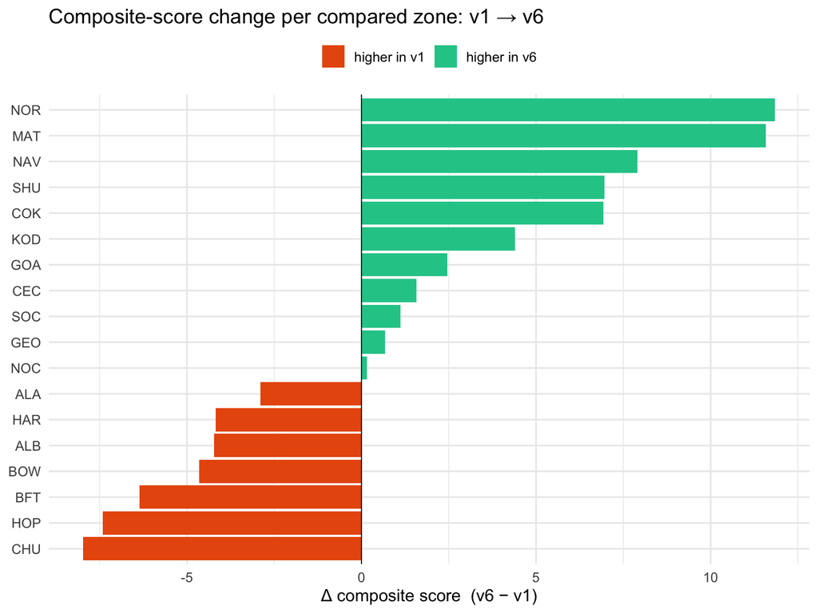

```r
d_plot <- d |>
  mutate(zone_key = factor(zone_key, levels = zone_key[order(delta)]),
         sign = ifelse(delta >= 0, glue("higher in {vb}"), glue("higher in {va}")))

ggplot(d_plot, aes(delta, zone_key, fill = sign)) +
  geom_col() +
  geom_vline(xintercept = 0, linewidth = 0.3) +
  scale_fill_manual(values = setNames(c("#20c997", "#e8590c"),
                                      c(glue("higher in {vb}"), glue("higher in {va}")))) +
  labs(x = glue("Δ composite score  ({vb} − {va})"), y = NULL, fill = NULL,
       title = glue("Composite-score change per compared zone: {va} → {vb}")) +
  theme_minimal(base_size = 12) +
  theme(legend.position = "top")
```

## 4 Component scores

`msens::zone_score_delta()` compares only shared zones and metrics and **returns what it had to drop**, so a component one release lacks is listed, never compared against nothing.

```r
is_component <- function(m) grepl("^extrisk_[a-z_]+_ecoregion_rescaled$", m) |
                            m == "primprod_ecoregion_rescaled"
comp_label <- function(m) ifelse(m == "primprod_ecoregion_rescaled", "primary productivity",
                                 sub("^extrisk_(.*)_ecoregion_rescaled$", "\\1", m))
comp_title <- function(m) tools::toTitleCase(gsub("_", " ", comp_label(m)))

comps <- zd$by_metric |>
  filter(is_component(metric_key)) |>
  mutate(component = comp_label(metric_key)) |>
  arrange(desc(mean_abs_delta))

only_a <- zd$metrics_only_a[is_component(zd$metrics_only_a)]
only_b <- zd$metrics_only_b[is_component(zd$metrics_only_b)]

cat(glue("- components compared: **{nrow(comps)}**  \n",
         "- components only in {va} (listed, not compared): ",
         if (length(only_a)) paste0("`", only_a, "`", collapse = ", ") else "none", "  \n",
         "- components only in {vb} (listed, not compared): ",
         if (length(only_b)) paste0("`", only_b, "`", collapse = ", ") else "none", "\n"))
```

```
- components compared: **7**
- components only in v1 (listed, not compared): `extrisk_all_ecoregion_rescaled`, `extrisk_reptile_ecoregion_rescaled`
- components only in v6 (listed, not compared): `extrisk_turtle_ecoregion_rescaled`
```

### 4.1 Summary by component

```r
comps |>
  transmute(component, metric_key, n = n_zones,
            !!glue("mean {va}") := round(mean_a, 2), !!glue("mean {vb}") := round(mean_b, 2),
            `mean Δ` = round(mean_delta, 2), `mean |Δ|` = round(mean_abs_delta, 2),
            `max |Δ|` = round(max_abs_delta, 2), r = round(cor, 3)) |>
  DT::datatable(rownames = FALSE, options = list(dom = "t", pageLength = 25),
                caption = glue("Per-component delta over the compared zones, {va} → {vb}, sorted by mean |Δ|"))
```

| component | metric_key | n | mean v1 | mean v6 | mean Δ | mean \|Δ\| | max \|Δ\| | r |
| --- | --- | --- | --- | --- | --- | --- | --- | --- |
| bird | extrisk_bird_ecoregion_rescaled | 18 | 34.17 | 51.94 | 17.77 | 24.66 | 57.94 | 0.582 |
| fish | extrisk_fish_ecoregion_rescaled | 18 | 28.99 | 22.36 | -6.63 | 12.21 | 26.16 | 0.785 |
| mammal | extrisk_mammal_ecoregion_rescaled | 18 | 55.09 | 53.04 | -2.05 | 8.4 | 20.53 | 0.857 |
| coral | extrisk_coral_ecoregion_rescaled | 18 | 15.74 | 14.17 | -1.57 | 1.78 | 19.46 | 0.892 |
| invertebrate | extrisk_invertebrate_ecoregion_rescaled | 18 | 20.87 | 21.02 | 0.14 | 0.27 | 1.97 | 1 |
| primary productivity | primprod_ecoregion_rescaled | 18 | 8.89 | 8.84 | -0.05 | 0.05 | 0.31 | 1 |
| other | extrisk_other_ecoregion_rescaled | 18 | 18.43 | 18.42 | -0.02 | 0.03 | 0.15 | 1 |

### 4.2 Δ by zone × component

One cell per (compared zone, component): Δ = B − A. Sort any column to find where a component moved most.

```r
comp_keys  <- comps$metric_key
comp_delta <- setNames(lapply(comp_keys, metric_delta), comp_keys)

wide <- bind_rows(
    lapply(comp_keys, function(m) comp_delta[[m]] |> transmute(zone_key, component = comp_label(m), delta)),
    d |> transmute(zone_key, component = "COMPOSITE", delta)) |>
  mutate(delta = round(delta, 2)) |>
  pivot_wider(names_from = component, values_from = delta) |>
  left_join(names_draw |> filter(status == "compared") |> select(key_b, zone_name, region), by = c("zone_key" = "key_b")) |>
  relocate(zone_key, zone_name, region, COMPOSITE) |>
  rename(Zone = zone_key, Name = zone_name, Region = region) |>
  arrange(desc(abs(COMPOSITE)))

num_cols <- names(wide)[sapply(wide, is.numeric)]
ds <- div_style(unlist(wide[num_cols]), n = 10)
DT::datatable(wide, rownames = FALSE, options = list(dom = "t", pageLength = 40, scrollX = TRUE),
              caption = glue("Δ ({vb} − {va}) per compared zone and component")) |>
  DT::formatStyle(num_cols, backgroundColor = DT::styleInterval(ds$brks, ds$cols))
```

| Zone | Name | Region | COMPOSITE | bird | fish | mammal | coral | invertebrate | primary productivity | other |
| --- | --- | --- | --- | --- | --- | --- | --- | --- | --- | --- |
| NOR | Norton Basin | AK | 11.84 | 57.94 | 6.58 | 18.36 | 0 | 0.07 | -0.08 | 0.03 |
| MAT | St. Matthew-Hall | AK | 11.59 | 47.36 | 5.29 | 17.17 | 0 | 0.04 | -0.07 | 0 |
| CHU | Chukchi Sea | AK | -7.97 | -9.91 | -25.03 | -20.53 | -0.31 | 0 | 0 | 0 |
| NAV | Navarin Basin | AK | 7.91 | 44.29 | 3.84 | 12.3 | 0.01 | 0.17 | 0 | -0.03 |
| HOP | Hope Basin | AK | -7.41 | -35.79 | -8.21 | -7.95 | 0 | 0.15 | -0.06 | 0 |
| SHU | Shumagin | AK | 6.95 | 41.89 | -8.66 | -4.96 | 0 | 0.03 | -0.01 | -0.03 |
| COK | Cook Inlet | AK | 6.93 | 7.7 | 26.16 | -1.08 | 0 | 0.06 | -0.3 | -0.15 |
| BFT | Beaufort Sea | AK | -6.36 | -9.47 | -9.26 | -15.47 | -10.3 | -0.03 | 0 | 0 |
| BOW | Bowers Basin | AK | -4.65 | 15 | -14.64 | 1.87 | 0 | -0.05 | 0 | 0.03 |
| KOD | Kodiak | AK | 4.4 | 28.56 | -11.02 | -8.7 | 0 | 0.03 | -0.01 | -0.04 |

[output cut: 8 more lines]

### 4.3 Each component: map and table

**Bird**

`extrisk_bird_ecoregion_rescaled` — 18 zones compared; mean |Δ| 24.66, max |Δ| 57.94, r = 0.582.

[interactive chart not shown]

| Planning Area (v1) | Program Area (v6) | Name | Region | v1 | v6 | Δ | Δ % |
| --- | --- | --- | --- | --- | --- | --- | --- |
| NOR | NOR | Norton Basin | AK | 33.91 | 91.85 | 57.94 | 170.9 |
| MAT | MAT | St. Matthew-Hall | AK | 31.61 | 78.96 | 47.36 | 149.8 |
| NAV | NAV | Navarin Basin | AK | 13.35 | 57.64 | 44.29 | 331.9 |
| SHU | SHU | Shumagin | AK | 30.07 | 71.97 | 41.89 | 139.3 |
| HOP | HOP | Hope Basin | AK | 74.51 | 38.72 | -35.79 | -48 |
| GEO | GEO | St. George Basin | AK | 32.1 | 64.82 | 32.72 | 101.9 |
| CEC | CEC | Central California | PA | 30.58 | 60.17 | 29.59 | 96.8 |
| KOD | KOD | Kodiak | AK | 45.32 | 73.89 | 28.56 | 63 |
| SOC | SOC | Southern California | PA | 36.04 | 63.37 | 27.33 | 75.8 |
| NOC | NOC | Northern California | PA | 22.94 | 48.32 | 25.38 | 110.7 |

[output cut: 8 more lines]

**Fish**

`extrisk_fish_ecoregion_rescaled` — 18 zones compared; mean |Δ| 12.21, max |Δ| 26.16, r = 0.785.

[interactive chart not shown]

| Planning Area (v1) | Program Area (v6) | Name | Region | v1 | v6 | Δ | Δ % |
| --- | --- | --- | --- | --- | --- | --- | --- |
| COK | COK | Cook Inlet | AK | 43.82 | 69.97 | 26.16 | 59.7 |
| CHU | CHU | Chukchi Sea | AK | 41.79 | 16.76 | -25.03 | -59.9 |
| SOC | SOC | Southern California | PA | 42.04 | 23.36 | -18.68 | -44.4 |
| NOC | NOC | Northern California | PA | 28.73 | 11.27 | -17.46 | -60.8 |
| CEC | CEC | Central California | PA | 28.55 | 12.13 | -16.42 | -57.5 |
| ALA | ALA | Aleutian Arc | AK | 36.42 | 20.52 | -15.9 | -43.7 |
| GOA | GOA | Gulf of Alaska | AK | 43.12 | 28.07 | -15.04 | -34.9 |
| BOW | BOW | Bowers Basin | AK | 22.48 | 7.84 | -14.64 | -65.1 |
| KOD | KOD | Kodiak | AK | 37.25 | 26.23 | -11.02 | -29.6 |
| BFT | BFT | Beaufort Sea | AK | 12.79 | 3.53 | -9.26 | -72.4 |

[output cut: 8 more lines]

**Mammal**

`extrisk_mammal_ecoregion_rescaled` — 18 zones compared; mean |Δ| 8.4, max |Δ| 20.53, r = 0.857.

[interactive chart not shown]

| Planning Area (v1) | Program Area (v6) | Name | Region | v1 | v6 | Δ | Δ % |
| --- | --- | --- | --- | --- | --- | --- | --- |
| CHU | CHU | Chukchi Sea | AK | 65.9 | 45.37 | -20.53 | -31.2 |
| NOR | NOR | Norton Basin | AK | 35.64 | 54 | 18.36 | 51.5 |
| MAT | MAT | St. Matthew-Hall | AK | 31.95 | 49.12 | 17.17 | 53.7 |
| BFT | BFT | Beaufort Sea | AK | 34.63 | 19.16 | -15.47 | -44.7 |
| NAV | NAV | Navarin Basin | AK | 58.81 | 71.11 | 12.3 | 20.9 |
| NOC | NOC | Northern California | PA | 69.55 | 59.24 | -10.31 | -14.8 |
| KOD | KOD | Kodiak | AK | 54.8 | 46.11 | -8.7 | -15.9 |
| CEC | CEC | Central California | PA | 62.15 | 54.14 | -8 | -12.9 |
| HOP | HOP | Hope Basin | AK | 91.75 | 83.8 | -7.95 | -8.7 |
| GOA | GOA | Gulf of Alaska | AK | 71.23 | 63.29 | -7.94 | -11.2 |

[output cut: 8 more lines]

**Coral**

`extrisk_coral_ecoregion_rescaled` — 18 zones compared; mean |Δ| 1.78, max |Δ| 19.46, r = 0.892.

[interactive chart not shown]

| Planning Area (v1) | Program Area (v6) | Name | Region | v1 | v6 | Δ | Δ % |
| --- | --- | --- | --- | --- | --- | --- | --- |
| HAR | HAR | High Arctic | AK | 20.99 | 1.54 | -19.46 | -92.7 |
| BFT | BFT | Beaufort Sea | AK | 17.3 | 7 | -10.3 | -59.5 |
| SOC | SOC | Southern California | PA | 16.63 | 17.46 | 0.83 | 5 |
| NOC | NOC | Northern California | PA | 8.57 | 9.19 | 0.62 | 7.3 |
| CEC | CEC | Central California | PA | 5.78 | 6.2 | 0.42 | 7.3 |
| CHU | CHU | Chukchi Sea | AK | 14.56 | 14.24 | -0.31 | -2.1 |
| ALB | ALB | Aleutian Basin | AK | 5.55 | 5.56 | 0.01 | 0.1 |
| NAV | NAV | Navarin Basin | AK | 8.91 | 8.92 | 0.01 | 0.1 |
| GEO | GEO | St. George Basin | AK | 26.56 | 26.55 | 0 | 0 |
| MAT | MAT | St. Matthew-Hall | AK | 4.76 | 4.75 | 0 | -0.1 |

[output cut: 8 more lines]

**Invertebrate**

`extrisk_invertebrate_ecoregion_rescaled` — 18 zones compared; mean |Δ| 0.27, max |Δ| 1.97, r = 1.

[interactive chart not shown]

| Planning Area (v1) | Program Area (v6) | Name | Region | v1 | v6 | Δ | Δ % |
| --- | --- | --- | --- | --- | --- | --- | --- |
| CEC | CEC | Central California | PA | 4.96 | 6.92 | 1.97 | 39.7 |
| SOC | SOC | Southern California | PA | 17.02 | 17.66 | 0.64 | 3.7 |
| HAR | HAR | High Arctic | AK | 15.87 | 15.31 | -0.55 | -3.5 |
| NOC | NOC | Northern California | PA | 8.7 | 8.21 | -0.49 | -5.6 |
| ALA | ALA | Aleutian Arc | AK | 14.47 | 14.72 | 0.25 | 1.8 |
| GEO | GEO | St. George Basin | AK | 31.81 | 32.05 | 0.24 | 0.8 |
| NAV | NAV | Navarin Basin | AK | 13.45 | 13.62 | 0.17 | 1.3 |
| HOP | HOP | Hope Basin | AK | 68.02 | 68.17 | 0.15 | 0.2 |
| NOR | NOR | Norton Basin | AK | 11.92 | 11.99 | 0.07 | 0.6 |
| COK | COK | Cook Inlet | AK | 44.03 | 44.1 | 0.06 | 0.1 |

[output cut: 8 more lines]

**Primary Productivity**

`primprod_ecoregion_rescaled` — 18 zones compared; mean |Δ| 0.05, max |Δ| 0.31, r = 1.

[interactive chart not shown]

| Planning Area (v1) | Program Area (v6) | Name | Region | v1 | v6 | Δ | Δ % |
| --- | --- | --- | --- | --- | --- | --- | --- |
| HAR | HAR | High Arctic | AK | 4.9 | 4.59 | -0.31 | -6.4 |
| COK | COK | Cook Inlet | AK | 21.22 | 20.92 | -0.3 | -1.4 |
| NOR | NOR | Norton Basin | AK | 20.12 | 20.04 | -0.08 | -0.4 |
| MAT | MAT | St. Matthew-Hall | AK | 9.92 | 9.85 | -0.07 | -0.7 |
| HOP | HOP | Hope Basin | AK | 27.35 | 27.29 | -0.06 | -0.2 |
| SOC | SOC | Southern California | PA | 9.59 | 9.56 | -0.03 | -0.3 |
| CEC | CEC | Central California | PA | 12.02 | 12 | -0.02 | -0.2 |
| GOA | GOA | Gulf of Alaska | AK | 9.92 | 9.9 | -0.02 | -0.2 |
| SHU | SHU | Shumagin | AK | 4.98 | 4.97 | -0.01 | -0.3 |
| KOD | KOD | Kodiak | AK | 7.71 | 7.71 | -0.01 | -0.1 |

[output cut: 8 more lines]

**Other**

`extrisk_other_ecoregion_rescaled` — 18 zones compared; mean |Δ| 0.03, max |Δ| 0.15, r = 1.

[interactive chart not shown]

| Planning Area (v1) | Program Area (v6) | Name | Region | v1 | v6 | Δ | Δ % |
| --- | --- | --- | --- | --- | --- | --- | --- |
| COK | COK | Cook Inlet | AK | 41.4 | 41.24 | -0.15 | -0.4 |
| GEO | GEO | St. George Basin | AK | 30.66 | 30.58 | -0.08 | -0.3 |
| KOD | KOD | Kodiak | AK | 16.71 | 16.67 | -0.04 | -0.3 |
| BOW | BOW | Bowers Basin | AK | 9.57 | 9.6 | 0.03 | 0.4 |
| NOR | NOR | Norton Basin | AK | 7.33 | 7.37 | 0.03 | 0.5 |
| SHU | SHU | Shumagin | AK | 15.84 | 15.8 | -0.03 | -0.2 |
| ALB | ALB | Aleutian Basin | AK | 4.89 | 4.92 | 0.03 | 0.6 |
| NAV | NAV | Navarin Basin | AK | 16.89 | 16.86 | -0.03 | -0.2 |
| GOA | GOA | Gulf of Alaska | AK | 23.22 | 23.2 | -0.03 | -0.1 |
| SOC | SOC | Southern California | PA | 15.45 | 15.43 | -0.02 | -0.1 |

[output cut: 8 more lines]

### 4.4 Components present in only one version

Listed for reference, **not** compared: their score per zone in the version that has them.

```r
one_sided <- bind_rows(
  scores_a |> filter(metric_key %in% only_a) |> mutate(version = va, unit = unit_label[[unit_a]]),
  scores_b |> filter(metric_key %in% only_b) |> mutate(version = vb, unit = unit_label[[unit_b]]))
if (nrow(one_sided)) {
  one_sided |>
    transmute(version, unit, component = comp_label(metric_key), metric_key, zone = zone_key,
              score = round(score, 2)) |>
    DT::datatable(rownames = FALSE, filter = "top", options = list(pageLength = 25))
} else cat("none — both versions carry the same components.\n")
```

| version | unit | component | metric_key | zone | score |
| --- | --- | --- | --- | --- | --- |
| v1 | Planning Area | all | extrisk_all_ecoregion_rescaled | ALA | 26.31 |
| v1 | Planning Area | reptile | extrisk_reptile_ecoregion_rescaled | ALA | 75.53 |
| v1 | Planning Area | all | extrisk_all_ecoregion_rescaled | ALB | 5.27 |
| v1 | Planning Area | reptile | extrisk_reptile_ecoregion_rescaled | ALB | 46.74 |
| v1 | Planning Area | all | extrisk_all_ecoregion_rescaled | AMS | 1.71 |
| v1 | Planning Area | reptile | extrisk_reptile_ecoregion_rescaled | AMS | 2.93 |
| v1 | Planning Area | all | extrisk_all_ecoregion_rescaled | BFT | 20.08 |
| v1 | Planning Area | all | extrisk_all_ecoregion_rescaled | BOW | 14.64 |
| v1 | Planning Area | reptile | extrisk_reptile_ecoregion_rescaled | BOW | 57.83 |
| v1 | Planning Area | all | extrisk_all_ecoregion_rescaled | CEC | 11.41 |

[output cut: 68 more lines]

## 5 All metrics, long form

Every (compared zone, metric) present in both versions — the composite, the components, and the intermediate metrics (`extrisk_*` raw, ecoregion min/max, pre-area-weighting backups). Filter with the boxes above each column and sort by any column.

```r
shared_m <- zd$by_metric$metric_key
long <- bind_rows(lapply(shared_m, function(m) metric_delta(m) |> mutate(metric_key = m))) |>
  left_join(names_draw |> filter(status == "compared") |> select(key_b, region), by = c("zone_key" = "key_b")) |>
  transmute(Zone = zone_key, Region = region, metric_key,
            !!va := round(.data[[va_col]], 3), !!vb := round(.data[[vb_col]], 3),
            `Δ` = round(delta, 3),
            `Δ %` = ifelse(.data[[va_col]] != 0, round(100 * delta / .data[[va_col]], 1), NA)) |>
  arrange(desc(abs(`Δ`)))
DT::datatable(long, rownames = FALSE, filter = "top",
              options = list(pageLength = 20, order = list(list(5, "desc"))),
              caption = glue("{nrow(long)} (zone × metric) pairs shared by {va} and {vb}"))
```

| Zone | Region | metric_key | v1 | v6 | Δ | Δ % |
| --- | --- | --- | --- | --- | --- | --- |
| SOC | PA | extrisk_fish | 6624.571 | 465.551 | -6159.02 | -93 |
| COK | AK | extrisk_invertebrate | 6020.908 | 296.549 | -5724.36 | -95.1 |
| NOC | PA | extrisk_fish | 4975.762 | 343.156 | -4632.606 | -93.1 |
| CEC | PA | extrisk_fish | 4961.569 | 351.944 | -4609.625 | -92.9 |
| GOA | AK | extrisk_fish | 4223.1 | 408.946 | -3814.154 | -90.3 |
| ALA | AK | extrisk_fish | 3958.286 | 251.414 | -3706.872 | -93.6 |
| GOA | AK | extrisk_invertebrate | 3798.159 | 187.064 | -3611.095 | -95.1 |
| KOD | AK | extrisk_fish | 3809.11 | 388.219 | -3420.891 | -89.8 |
| COK | AK | extrisk_fish | 4272.55 | 880.725 | -3391.825 | -79.4 |
| SHU | AK | extrisk_fish | 3692.174 | 396.179 | -3295.995 | -89.3 |

[output cut: 260 more lines]